# The Bootstrap

Ednita J Tavarez-Jimenez

## Penguin Parametric CI

**Q1: What is the sample size, n?**

The sample size is 123L

```r
require(palmerpenguins)
Gentoo = subset(penguins, species == "Gentoo")

n = sum(!is.na(Gentoo$bill_length_mm))
```

**Q2: What is the sample standard deviation?**

The Standard Deviation is .089.

```r
sd((!is.na(Gentoo$bill_length_mm)))
```

```
## [1] 0.08980265
```

**Q3: What are the critical t-values?**

The critical t-value is 1.979

```r
alpha = 0.05
t_crit = abs(qt(alpha / 2, df = n - 1))
```

**Q4: What is the sample standard error?

The sample standard error is 0.277

```r
sse_gentoo = sd(Gentoo$bill_length_mm, na.rm = TRUE) / sqrt(n)
```

**Q5: Finally construct the CI**

```r
# The CI is the sample mean +/- the radius:
mean(Gentoo$bill_length_mm, trim = 0, na.rm = TRUE)
```

```
## [1] 47.50488
```

```r
# 4: Calculate the CI radius:
gentoo_radius = sse_gentoo * t_crit

Gentoo_ci = c(
  lower = mean(Gentoo$bill_length_mm, na.rm = TRUE) - gentoo_radius,
  upper = mean(Gentoo$bill_length_mm, na.rm = TRUE) + gentoo_radius)

print(round(Gentoo_ci, 4))
```

```
##   lower   upper
## 46.9548 48.0550
```

## Penguin Bootstrap

**Q7: Show the r code you used to call the boot() function.**

```r
m = 10000
result = numeric(m)
head(result)
```

```
## [1] 0 0 0 0 0 0
```

```r
for(i in 1:m)
{
  result[i] = mean(sample(Gentoo$bill_length_mm, m, replace=TRUE, !is.na(Gentoo$bill_length_mm)))
}

mean(result)
```

```
## [1] 47.50452
```

```r
quantile(result,c(0.025,0.975))
```

```
##     2.5%    97.5%
## 47.44418 47.56487
```

```r
#install.packages("boot")
require(boot)
boot_mean = function(x, i)
{
  return(mean(x[i], na.rm = TRUE))
}

myboot_bill =
  boot(
    data = Gentoo$bill_length_mm,
    statistic = boot_mean,
    R = 10000)

print(myboot_bill)
```

```
##
## ORDINARY NONPARAMETRIC BOOTSTRAP
##
##
## Call:
## boot(data = Gentoo$bill_length_mm, statistic = boot_mean, R = 10000)
##
##
## Bootstrap Statistics :
##     original       bias    std. error
## t1* 47.50488 -0.002113491   0.2765776
```

**Q8: Show the r code you used to calculate the upper and lower 2.5% quantiles.**

```r
str(myboot_bill)
```

```
## List of 11
##  $ t0       : num 47.5
##  $ t        : num [1:10000, 1] 47.7 47.3 47.7 47.1 47.4 ...
##  $ R        : num 10000
##  $ data     : num [1:124] 46.1 50 48.7 50 47.6 46.5 45.4 46.7 43.3 46.8 ...
##  $ seed     : int [1:626] 10403 256 397453842 1289864662 1118879037 -1469815342 1044267597 829727030 -1921886600 -632627725 ...
##  $ statistic:function (x, i)
##   ..- attr(*, "srcref")= 'srcref' int [1:8] 14 13 17 1 13 1 14 17
##   .. ..- attr(*, "srcfile")=Classes 'srcfilecopy', 'srcfile' <environment: 0x7fb049835f40>
##  $ sim      : chr "ordinary"
##  $ call     : language boot(data = Gentoo$bill_length_mm, statistic = boot_mean, R = 10000)
##  $ stype    : chr "i"
##  $ strata   : num [1:124] 1 1 1 1 1 1 1 1 1 1 ...
##  $ weights  : num [1:124] 0.00806 0.00806 0.00806 0.00806 0.00806 ...
##  - attr(*, "class")= chr "boot"
##  - attr(*, "boot_type")= chr "boot"
```

```r
mean(sample(Gentoo$bill_length_mm, m, replace=TRUE, !is.na(Gentoo$bill_length_mm)))
```

```
## [1] 47.55644
```

```r
myboot_bill$t0
```

```
## [1] 47.50488
```

```r
mean(myboot_bill$t) - myboot_bill$t0
```

```
## [1] -0.002113491
```

```r
sd(myboot_bill$t)
```

```
## [1] 0.2765776
```

```r
quantile(
  myboot_bill$t,
  c(0.025, 0.975))
```

```
##     2.5%    97.5%
## 46.96851 48.04917
```

## Refaction Sampler

**Q9: Show your completed rarefaction_sampler() function.

```r
require(here)
moths = read.csv(here("data", "moths.csv"))
head(moths)
```

```
##   site itame mepi cime  anst cahe  bare   acal   apde psca euma
## 1    4     0    0    0 1.000  1.0 0.000  0.667  2.500  0.0 0.00
## 2    5     0    0    0 1.000  0.0 0.000  0.000  0.000  1.5 0.00
## 3    6     0    2    0 0.000  2.5 0.000  0.667 10.000  0.0 0.00
## 4    7     0    0    3 5.000  0.0 1.667  0.500  2.333  1.5 0.00
## 5    8     0    0    0 0.000  4.5 0.000  0.667  4.000  3.0 0.75
## 6    9     5    0    0 6.333  1.0 1.667 16.667  1.333  7.0 2.75
```

```r
moth_dat = moths[,-1]
head(moth_dat)
```

```
##   itame mepi cime  anst cahe  bare   acal   apde psca euma
## 1     0    0    0 1.000  1.0 0.000  0.667  2.500  0.0 0.00
## 2     0    0    0 1.000  0.0 0.000  0.000  0.000  1.5 0.00
## 3     0    2    0 0.000  2.5 0.000  0.667 10.000  0.0 0.00
## 4     0    0    3 5.000  0.0 1.667  0.500  2.333  1.5 0.00
## 5     0    0    0 0.000  4.5 0.000  0.667  4.000  3.0 0.75
## 6     5    0    0 6.333  1.0 1.667 16.667  1.333  7.0 2.75
```

```r
rarefaction_sampler = function(input_dat, n_iterations)
{
  n = nrow(moth_dat) #number of rows or sample observations
  m = 100

  n_input_rows = nrow(input_dat)

  results_out = matrix(
    nrow = n_iterations,
    ncol = n_input_rows)

  # The outer loop: runs once for each bootstrap iteration.  index variable is i
  for(i in 1:n_iterations)
  {
    # The inner loop: simulates increasing sampling intensity
    # Sampling intensity ranges from 1 site to the complete count of
    # sites in the input data (n)
    # index variable is j
    for(j in 1:n)
    {
      # sample the input data row indices, with replacement
      rows_j = sample(n, size = j, replace=TRUE)

      # Creates a new data matrix
      t1 = input_dat[rows_j, ]

      # Calculates the column sums
      t2 = apply(t1, 2, sum)

      # Counts the number of columns in which any moths were observed
      results_out[i, j] = sum(t2 > 0)
    }
  }
  return(results_out)
}

rarefact = rarefaction_sampler(moth_dat, 100)
head(rarefact)
```

```
##      [,1] [,2] [,3] [,4] [,5] [,6] [,7] [,8] [,9] [,10] [,11] [,12] [,13] [,14]
## [1,]    3    6    7    9    9   10   10   10    9    10    10    10    10    10
## [2,]    4    5    4   10    8   10    9   10   10     9    10    10     9     9
## [3,]    4    8    8    8    9   10    6    8   10    10    10    10    10    10
## [4,]    2    4    6    9    8   10    9   10    9    10    10    10    10    10
## [5,]    3    5    9    6    9    8   10   10   10    10    10    10    10    10
## [6,]    6    8    6    8    8    8   10    8   10     8     9    10     9    10
##      [,15] [,16] [,17] [,18] [,19] [,20] [,21] [,22] [,23] [,24]
## [1,]    10    10    10    10    10    10    10    10    10    10
## [2,]    10    10    10    10    10    10    10    10    10    10
## [3,]    10    10    10    10    10    10    10    10    10    10
## [4,]    10    10    10    10    10    10    10    10    10    10
## [5,]    10    10    10    10    10    10    10    10    10    10
## [6,]     9    10    10    10    10    10    10    10    10    10
```

**Q10 (1 pt.): What did you find most difficult about building the function?**

Having to figure out and understand how to get the code to work. I only found one thing wrong with it to make it work.

**Q11 (4 pts.): Show the code you used to perform the simulations and construct the curve.**

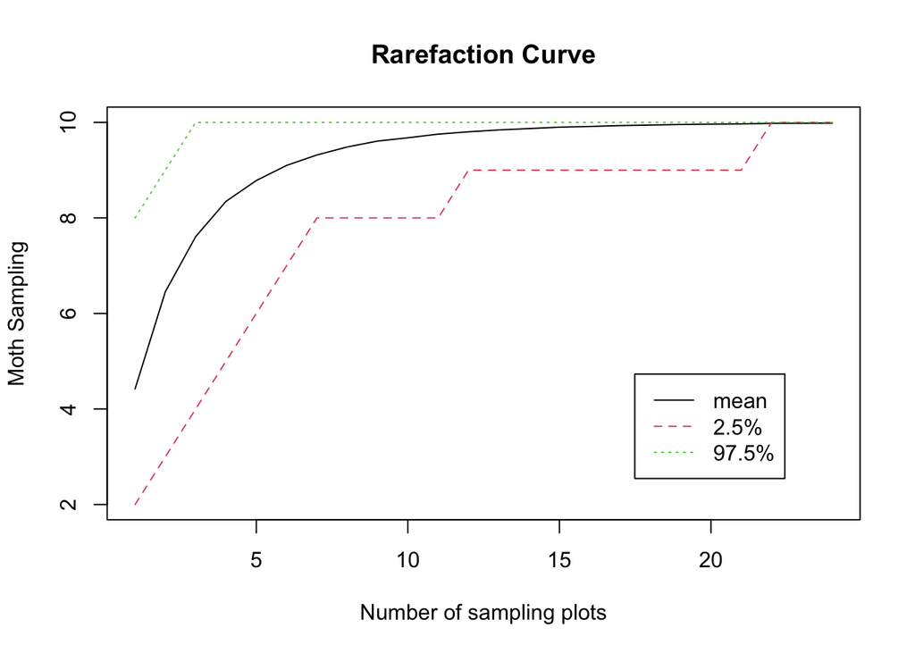

```r
moths = read.csv(here("data", "moths.csv"))
rarefact = rarefaction_sampler(moths[,-1], 10000)

rare_mean = apply(rarefact, 2, mean)
rare_quant = apply(rarefact, 2, quantile, probs=c(0.025, 0.975))
rare = t(rbind(rare_mean, rare_quant))

matplot(
  rare,
  type='l',
  xlab='Number of sampling plots',
  ylab='Moth Sampling',
  main="Rarefaction Curve")

legend(
  'bottomright',
  legend=c('mean','2.5%','97.5%'),
  lty=c(1,2,3),col=c(1,2,3), inset=c(.1,.1))
```

**Q13 (2 pts.): About how many sites should you visit if you want to see all of the moth species? Explain your reasoning using your rarefaction curve figure.**

I would visit about 23 sites because thats where the 97.5%, 2.5% and the mean meet where its the highest number of sampling.